# PokerHand

Fernando e Leonardo

01/10/2019

# Avaliação

# Introdução

Esse trabalho analisa um `dataset` de mãos de Poker que consistem de 5 cartas. O objetivo é analisar as 5 cartas e estimar qual é a mão para aquele jogo.

# Tipos de mãos do Poker

| Classe | Nome | Descrição |
| --- | --- | --- |
| 0 | Carta mais alta | Nenhuma mão de Poker, vence quem possuir a carta mais alta |
| 1 | Um par | Duas cartas de mesmo valor |
| 2 | Dois pares | Dois valores se repetem entre as 5 cartas |
| 3 | Trinca | Três cartas de valores iguais |
| 4 | Sequência | 5 cartas em sequência, sem interrupção |
| 5 | Flush | 5 cartas de mesmo naipe |
| 6 | Full House | Uma trinca e um par na mesma mão |
| 7 | Quadra | 4 cartas de mesmo valor |
| 8 | Straight Flush | 5 cartas em sequência e do mesmo naipe, sem lacunas |
| 9 | Royal Flush | Sequência Dez, Valete, Dama, Rei e Ás, do mesmo naipe |

A ordem dessa tabela é da mão mais baixa à mão mais alta. A que possui número de classe maior vence sobre as mãos de classe menor.

# Estrutura do Dataset

O dataset PokerHands possui as seguintes colunas: 1) S1 - Naipe da carta #1: Ordinal (1-4) representando o naipe (Copas, Espadas, Ouros, Paus) 2) C1 - Valor da carta #1: Numérico (1-13) representando o valor ou número da carta (Ás, 2, 3, …, 10, Valete, Rainha, Rei) 3) S2 - Naipe da carta #2: Ordinal (1-4) representando o naipe 4) C2 - Valor da carta #2: Numérico (1-13) representando o valor 5) S3 - Naipe da carta #3: Ordinal (1-4) representando o naipe 6) C3 - Valor da carta #3: Numérico (1-13) representando o valor 7) S4 - Naipe da carta #4: Ordinal (1-4) representando o naipe 8) C4 - Valor da carta #4: Numérico (1-13) representando o valor 9) S5 - Naipe da carta #5: Ordinal (1-4) representando o naipe 10) C5 - Valor da carta #5: Numérico (1-13) representando o valor 11) CLASS - Classificação: Ordinal (0-9) representando a classe que essa mão representa

# Bibliotecas utilizadas

```r
library(readr) # Para carregamento do arquivo
library(sqldf) # Para executar SQLs sobre os DataSets
library(e1071) # Contém o algoritmo de Naïve Bayes
library(tidyr) # Para transformar colunas em observações
library(dplyr) # Para operações de seleção, agrupamento
```

```r
library(ggplot2)
library(data.table) # Para incluir sequencial em grupos
```

# Carregando o arquivo

Leitura do arquivo. Os dados serão lidos como “factors” porquê são variáveis ordinais discretas.

```r
pokerTreino <- read_csv("datasets/poker-hand-training-true.data", col_names = c ("S1","C1","S2","C2","S3","C3","S4","C4","S5","C5","CLASS"), col_types = cols(.default = col_factor()))
View(pokerTreino)
```

Leitura do arquivo de teste

```r
pokerTeste <- read_csv("datasets/poker-hand-testing.data", col_names = c ("S1","C1","S2","C2","S3","C3","S4","C4","S5","C5","CLASS"), col_types = cols(.default = col_factor()))
View(pokerTeste)
```

# Ajustes

```r
pokerTreino$CLASS <- factor(pokerTreino$CLASS, levels=c(0,1,2,3,4,5,6,7,8,9), ordered =TRUE)
pokerTeste$CLASS <- factor(pokerTeste$CLASS, levels=c(0,1,2,3,4,5,6,7,8,9), ordered =TRUE)
```

# Análise do arquivo

```r
str(pokerTreino)
```

```
## Classes 'spec_tbl_df', 'tbl_df', 'tbl' and 'data.frame': 25010 obs. of  11 variables:
##  $ S1   : Factor w/ 4 levels "1","2","3","4": 1 2 3 4 4 1 1 2 3 4 ...
##  $ C1   : Factor w/ 13 levels "10","11","12",..: 1 2 3 1 4 5 6 4 7 4 ...
##  $ S2   : Factor w/ 4 levels "1","2","3","4": 1 2 3 4 4 1 1 2 3 4 ...
##  $ C2   : Factor w/ 13 levels "11","13","4",..: 1 2 1 1 2 3 4 5 6 3 ...
##  $ S3   : Factor w/ 4 levels "1","2","3","4": 1 2 3 4 4 1 1 2 3 4 ...
##  $ C3   : Factor w/ 13 levels "13","10","1",..: 1 2 1 3 4 5 2 6 7 8 ...
##  $ S4   : Factor w/ 4 levels "1","2","3","4": 1 2 3 4 4 1 1 2 3 4 ...
##  $ C4   : Factor w/ 13 levels "12","10","13",..: 1 1 2 3 4 5 4 6 7 5 ...
##  $ S5   : Factor w/ 4 levels "1","2","3","4": 1 2 3 4 4 1 1 2 3 4 ...
##  $ C5   : Factor w/ 13 levels "1","12","10",..: 1 1 1 2 3 4 5 6 7 6 ...
##  $ CLASS: Ord.factor w/ 10 levels "0"<"1"<"2"<"3"<..: 10 10 10 10 10 9 9 9 9 9 ...
##  - attr(*, "spec")=
##   .. cols(
##   ..   .default = col_factor(),
##   ..   S1 = col_factor(levels = NULL, ordered = FALSE, include_na = FALSE),
##   ..   C1 = col_factor(levels = NULL, ordered = FALSE, include_na = FALSE),
##   ..   S2 = col_factor(levels = NULL, ordered = FALSE, include_na = FALSE),
##   ..   C2 = col_factor(levels = NULL, ordered = FALSE, include_na = FALSE),
##   ..   S3 = col_factor(levels = NULL, ordered = FALSE, include_na = FALSE),
##   ..   C3 = col_factor(levels = NULL, ordered = FALSE, include_na = FALSE),
##   ..   S4 = col_factor(levels = NULL, ordered = FALSE, include_na = FALSE),
##   ..   C4 = col_factor(levels = NULL, ordered = FALSE, include_na = FALSE),
##   ..   S5 = col_factor(levels = NULL, ordered = FALSE, include_na = FALSE),
##   ..   C5 = col_factor(levels = NULL, ordered = FALSE, include_na = FALSE),
##   ..   CLASS = col_factor(levels = NULL, ordered = FALSE, include_na = FALSE)
##   .. )
```

Sumário do arquivo

```r
summary(pokerTreino)
```

```
##  S1             C1        S2             C2        S3
##  1:6150   1      : 1982   1:6309   13     : 2007   1:6230
##  2:6298   9      : 1967   2:6244   1      : 1985   2:6208
##  3:6250   7      : 1961   3:6157   6      : 1956   3:6153
##  4:6312   8      : 1948   4:6300   12     : 1939   4:6419
##           2      : 1941            11     : 1931
##           12     : 1940            10     : 1922
##           (Other):13271            (Other):13270
##        C3        S4             C4        S5             C5
##  10     : 2000   1:6269   3      : 1999   1:6308   8      : 1994
##  12     : 1987   2:6248   2      : 1987   2:6172   1      : 1970
##  3      : 1965   3:6314   1      : 1983   3:6314   5      : 1963
##  4      : 1935   4:6179   11     : 1953   4:6216   2      : 1957
##  7      : 1927            9      : 1946            10     : 1948
##  5      : 1920            7      : 1943            4      : 1946
##  (Other):13276            (Other):13199            (Other):13232
##      CLASS
##  0      :12493
##  1      :10599
##  2      : 1206
##  3      :  513
##  4      :   93
##  5      :   54
##  (Other):   52
```

# Análise exploratória

Total de linhas nos datasets

```r
paste("Linhas no dataset de treino:", nrow(pokerTreino))
```

```
## [1] "Linhas no dataset de treino: 25010"
```

```r
paste("Linhas no dataset de teste:", nrow(pokerTeste))
```

```
## [1] "Linhas no dataset de teste: 1000000"
```

Visualização do início do DataSet

```r
head(pokerTreino)
```

```
## # A tibble: 6 x 11
##   S1    C1    S2    C2    S3    C3    S4    C4    S5    C5    CLASS
##   <fct> <fct> <fct> <fct> <fct> <fct> <fct> <fct> <fct> <fct> <ord>
## 1 1     10    1     11    1     13    1     12    1     1     9
## 2 2     11    2     13    2     10    2     12    2     1     9
## 3 3     12    3     11    3     13    3     10    3     1     9
## 4 4     10    4     11    4     1     4     13    4     12    9
## 5 4     1     4     13    4     12    4     11    4     10    9
## 6 1     2     1     4     1     5     1     3     1     6     8
```

Divisão dos registros no dataset

```r
sqldf('SELECT COUNT(1) AS [Quantidade],
              class,
              (CASE WHEN Class = 0 THEN "Nothing"
                   WHEN Class = 1 THEN "One pair"
                   WHEN Class = 2 THEN "Two pairs"
                   WHEN Class = 3 THEN "Three of a kind"
                   WHEN Class = 4 THEN "Straight"
                   WHEN Class = 5 THEN "Flush"
                   WHEN Class = 6 THEN "Full house"
                   WHEN Class = 7 THEN "Four of a kind"
                   WHEN Class = 8 THEN "Straight flush"
                   WHEN Class = 9 THEN "Royal flush"
              END) AS [TipoENG],
              ROUND(((CAST (COUNT(1) AS real)/(SELECT COUNT(1) FROM pokerTreino)) * 100),2) AS [%]
      FROM pokerTreino
      GROUP BY class
      ORDER BY [Quantidade] DESC')
```

```
##    Quantidade CLASS         TipoENG     %
## 1       12493     0         Nothing 49.95
## 2       10599     1        One pair 42.38
## 3        1206     2       Two pairs  4.82
## 4         513     3 Three of a kind  2.05
## 5          93     4        Straight  0.37
## 6          54     5           Flush  0.22
## 7          36     6      Full house  0.14
## 8           6     7  Four of a kind  0.02
## 9           5     8  Straight flush  0.02
## 10          5     9     Royal flush  0.02
```

Distribuição das classes

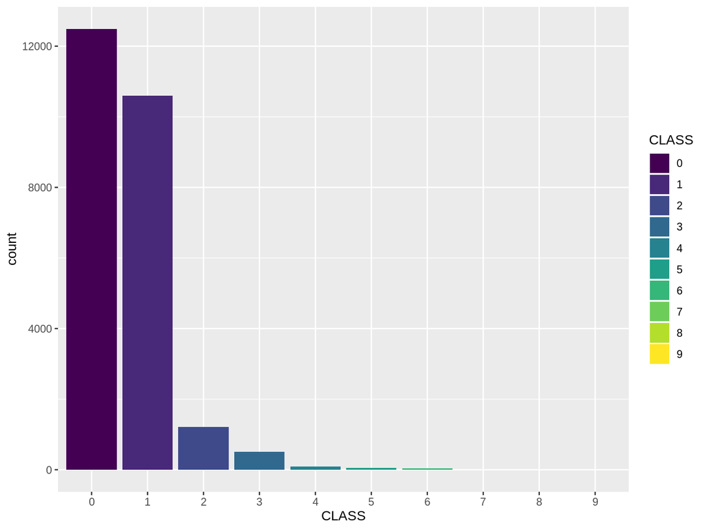

```r
ggplot(data = pokerTreino, aes(CLASS)) + geom_bar(aes(fill=CLASS))
```

```r
sqldf('SELECT DISTINCT
              COUNT(1) AS [Quantidade],
              class,
              (CASE WHEN Class = 0 THEN "Nothing"
                   WHEN Class = 1 THEN "One pair"
                   WHEN Class = 2 THEN "Two pairs"
                   WHEN Class = 3 THEN "Three of a kind"
                   WHEN Class = 4 THEN "Straight"
                   WHEN Class = 5 THEN "Flush"
                   WHEN Class = 6 THEN "Full house"
                   WHEN Class = 7 THEN "Four of a kind"
                   WHEN Class = 8 THEN "Straight flush"
                   WHEN Class = 9 THEN "Royal flush"
              END) AS [TipoENG],
              S1,
              C1,
              S2,
              C2,
              S3,
              C3,
              S4,
              C4,
              S5,
              C5
      FROM pokerTreino
      GROUP BY class, [TipoENG], S1, C1, S2, C2, S3, C3, S4, C4, S5, C5
      HAVING COUNT(1) > 1
      ORDER BY S1, C1, S2, C2, S3, C3, S4, C4, S5, C5  DESC')
```

```
##   Quantidade CLASS  TipoENG S1 C1 S2 C2 S3 C3 S4 C4 S5 C5
## 1          2     1 One pair  3 12  3  2  2  8  1  2  2  3
## 2          2     1 One pair  4  2  2  5  4  9  2  7  2  2
```

Quantidade de linhas onde as combinações são unicas: 25006 de 25010

```r
sqldf('SELECT DISTINCT
              COUNT(1) AS [Quantidade],
              class,
              (CASE WHEN Class = 0 THEN "Nothing"
                   WHEN Class = 1 THEN "One pair"
                   WHEN Class = 2 THEN "Two pairs"
                   WHEN Class = 3 THEN "Three of a kind"
                   WHEN Class = 4 THEN "Straight"
                   WHEN Class = 5 THEN "Flush"
                   WHEN Class = 6 THEN "Full house"
                   WHEN Class = 7 THEN "Four of a kind"
                   WHEN Class = 8 THEN "Straight flush"
                   WHEN Class = 9 THEN "Royal flush"
              END) AS [TipoENG],
              S1,
              C1,
              S2,
              C2,
              S3,
              C3,
              S4,
              C4,
              S5,
              C5
      FROM pokerTreino
      GROUP BY class, [TipoENG], S1, C1, S2, C2, S3, C3, S4, C4, S5, C5
      HAVING COUNT(1) = 1
      ORDER BY S1, C1, S2, C2, S3, C3, S4, C4, S5, C5  DESC')
```

```
##      Quantidade CLASS         TipoENG S1 C1 S2 C2 S3 C3 S4 C4 S5 C5
## 1             1     5           Flush  1  1  1 10  1 12  1  2  1  4
## 2             1     0         Nothing  1  1  1 10  1  4  2  2  1  9
## 3             1     0         Nothing  1  1  1 10  1  4  3  9  3  6
## 4             1     1        One pair  1  1  1 10  1  7  4  6  4 10
## 5             1     0         Nothing  1  1  1 10  1  9  2  3  1 11
## 6             1     3 Three of a kind  1  1  1 10  2  1  2  2  4  1
## 7             1     1        One pair  1  1  1 10  2  9  4  7  3 10
## 8             1     1        One pair  1  1  1 10  3 10  3  5  3 12
## 9             1     1        One pair  1  1  1 10  3 11  4  1  3  8
## 10            1     1        One pair  1  1  1 10  3  3  1 11  4  1
## 11            1     1        One pair  1  1  1 10  4  1  1  7  3  6
## 12            1     1        One pair  1  1  1 10  4  1  4  7  3  8
## 13            1     1        One pair  1  1  1 10  4  3  3  2  2  1
## 14            1     0         Nothing  1  1  1 10  4  5  3  8  4  7
```

[output cut: 7679 more lines]

Quantidade de números distinstos por coluna

```r
sqldf('SELECT DISTINCT
       S1,
       C1,
       COUNT(1) AS [Quantidade],
       ROUND(((CAST (COUNT(1) AS real)/(SELECT COUNT(1) FROM pokerTreino)) * 100),2) AS [%]
      FROM pokerTreino
      GROUP BY S1, C1
      ORDER BY [Quantidade] DESC')
```

```
##    S1 C1 Quantidade    %
## 1   4  1        529 2.12
## 2   1  8        524 2.10
## 3   2  9        521 2.08
## 4   3  4        514 2.06
## 5   2 11        511 2.04
## 6   4  9        511 2.04
## 7   4 12        510 2.04
## 8   2  7        509 2.04
## 9   4  7        506 2.02
## 10  2  1        505 2.02
## 11  3  2        503 2.01
## 12  4  4        496 1.98
## 13  2  5        495 1.98
## 14  3  1        493 1.97
```

[output cut: 38 more lines]

Quantidade de números distinstos por coluna

```r
sqldf('SELECT DISTINCT
       C1,
       S1,
       COUNT(1) AS [Quantidade],
       ROUND(((CAST (COUNT(1) AS real)/(SELECT COUNT(1) FROM pokerTreino)) * 100),2) AS [%]
      FROM pokerTreino
      GROUP BY C1
      ORDER BY [Quantidade] DESC')
```

```
##    C1 S1 Quantidade    %
## 1   1  2       1982 7.92
## 2   9  3       1967 7.86
## 3   7  1       1961 7.84
## 4   8  2       1948 7.79
## 5   2  3       1941 7.76
## 6  12  2       1940 7.76
## 7  11  2       1926 7.70
## 8   4  3       1919 7.67
## 9  13  1       1915 7.66
## 10  5  3       1892 7.56
## 11  3  3       1882 7.52
## 12 10  4       1877 7.50
## 13  6  2       1860 7.44
```

# Treinamento

Treinar com o Naïve Bayes

```r
pokerTreino <- data.frame(pokerTreino)
resultado <- naiveBayes(pokerTreino[,c("S1","C1","S2","C2","S3","C3","S4","C4","S5","C5")],pokerTreino[,c("CLASS")])
```

Como o algoritmo estruturou seus parâmetros:

```r
str(resultado)
```

```
## List of 5
##  $ apriori  : 'table' int [1:10(1d)] 12493 10599 1206 513 93 54 36 6 5 5
##   ..- attr(*, "dimnames")=List of 1
##   .. ..$ pokerTreino[, c("CLASS")]: chr [1:10] "0" "1" "2" "3" ...
##  $ tables   :List of 10
##   ..$ S1: 'table' num [1:10, 1:4] 0.247 0.248 0.217 0.234 0.301 ...
##   .. ..- attr(*, "dimnames")=List of 2
##   .. .. ..$ pokerTreino[, c("CLASS")]: chr [1:10] "0" "1" "2" "3" ...
##   .. .. ..$ S1                       : chr [1:4] "1" "2" "3" "4"
##   ..$ C1: 'table' num [1:10, 1:13] 0.0743 0.0754 0.0813 0.0643 0.086 ...
##   .. ..- attr(*, "dimnames")=List of 2
##   .. .. ..$ pokerTreino[, c("CLASS")]: chr [1:10] "0" "1" "2" "3" ...
##   .. .. ..$ C1                       : chr [1:13] "10" "11" "12" "1" ...
##   ..$ S2: 'table' num [1:10, 1:4] 0.253 0.252 0.256 0.25 0.237 ...
##   .. ..- attr(*, "dimnames")=List of 2
##   .. .. ..$ pokerTreino[, c("CLASS")]: chr [1:10] "0" "1" "2" "3" ...
##   .. .. ..$ S2                       : chr [1:4] "1" "2" "3" "4"
##   ..$ C2: 'table' num [1:10, 1:13] 0.0777 0.0772 0.0746 0.0682 0.0645 ...
##   .. ..- attr(*, "dimnames")=List of 2
##   .. .. ..$ pokerTreino[, c("CLASS")]: chr [1:10] "0" "1" "2" "3" ...
##   .. .. ..$ C2                       : chr [1:13] "11" "13" "4" "12" ...
##   ..$ S3: 'table' num [1:10, 1:4] 0.249 0.25 0.248 0.244 0.237 ...
##   .. ..- attr(*, "dimnames")=List of 2
##   .. .. ..$ pokerTreino[, c("CLASS")]: chr [1:10] "0" "1" "2" "3" ...
##   .. .. ..$ S3                       : chr [1:4] "1" "2" "3" "4"
##   ..$ C3: 'table' num [1:10, 1:13] 0.0772 0.0743 0.0862 0.0721 0.086 ...
##   .. ..- attr(*, "dimnames")=List of 2
##   .. .. ..$ pokerTreino[, c("CLASS")]: chr [1:10] "0" "1" "2" "3" ...
##   .. .. ..$ C3                       : chr [1:13] "13" "10" "1" "12" ...
##   ..$ S4: 'table' num [1:10, 1:4] 0.253 0.249 0.235 0.248 0.323 ...
##   .. ..- attr(*, "dimnames")=List of 2
##   .. .. ..$ pokerTreino[, c("CLASS")]: chr [1:10] "0" "1" "2" "3" ...
##   .. .. ..$ S4                       : chr [1:4] "1" "2" "3" "4"
##   ..$ C4: 'table' num [1:10, 1:13] 0.0721 0.0754 0.073 0.0624 0.086 ...
##   .. ..- attr(*, "dimnames")=List of 2
##   .. .. ..$ pokerTreino[, c("CLASS")]: chr [1:10] "0" "1" "2" "3" ...
##   .. .. ..$ C4                       : chr [1:13] "12" "10" "13" "11" ...
##   ..$ S5: 'table' num [1:10, 1:4] 0.249 0.254 0.265 0.259 0.226 ...
##   .. ..- attr(*, "dimnames")=List of 2
##   .. .. ..$ pokerTreino[, c("CLASS")]: chr [1:10] "0" "1" "2" "3" ...
##   .. .. ..$ S5                       : chr [1:4] "1" "2" "3" "4"
##   ..$ C5: 'table' num [1:10, 1:13] 0.0788 0.0772 0.0862 0.0994 0.0215 ...
##   .. ..- attr(*, "dimnames")=List of 2
##   .. .. ..$ pokerTreino[, c("CLASS")]: chr [1:10] "0" "1" "2" "3" ...
##   .. .. ..$ C5                       : chr [1:13] "1" "12" "10" "6" ...
##  $ levels   : chr [1:10] "0" "1" "2" "3" ...
##  $ isnumeric: Named logi [1:10] FALSE FALSE FALSE FALSE FALSE FALSE ...
##   ..- attr(*, "names")= chr [1:10] "S1" "C1" "S2" "C2" ...
##  $ call     : language naiveBayes.default(x = pokerTreino[, c("S1", "C1", "S2", "C2", "S3",      "C3", "S4", "C4", "S5", "C5")], y = pok| __truncated__
##  - attr(*, "class")= chr "naiveBayes"
```

```r
resultado$levels
```

```
##  [1] "0" "1" "2" "3" "4" "5" "6" "7" "8" "9"
```

```r
resultado$apriori
```

```
## pokerTreino[, c("CLASS")]
##     0     1     2     3     4     5     6     7     8     9
## 12493 10599  1206   513    93    54    36     6     5     5
```

Estrutura de cada parâmetro

```r
for (i in 0:9) {
   print(resultado$tables[i])
}
```

```
## named list()
## $S1
##                          S1
## pokerTreino[, c("CLASS")]         1         2         3         4
##                         0 0.2473385 0.2523813 0.2459777 0.2543024
##                         1 0.2477592 0.2511558 0.2524766 0.2486084
##                         2 0.2172471 0.2678275 0.2553897 0.2595357
##                         3 0.2339181 0.2397661 0.2612086 0.2651072
##                         4 0.3010753 0.1827957 0.3333333 0.1827957
##                         5 0.2222222 0.2037037 0.2222222 0.3518519
##                         6 0.2500000 0.1666667 0.3055556 0.2777778
##                         7 0.0000000 0.1666667 0.5000000 0.3333333
##                         8 0.4000000 0.2000000 0.2000000 0.2000000
##                         9 0.2000000 0.2000000 0.2000000 0.4000000
##
```

[output cut: 255 more lines]

Tentar predizer e verificar com o resultado

```r
pokerTeste$resultado_previsto <- predict(resultado, newdata = pokerTeste[1:10], type = "class")
View(pokerTeste)
```

Matriz de confusão

```r
matrizConfusao <- table(pokerTeste$resultado_previsto,pokerTeste$CLASS)
matrizConfusao
```

```
##
##          0      1      2      3      4      5      6      7      8      9
##   0 465870 394355  44744  19960   3525   1818   1369    223     11      3
##   1  35316  28042   2855   1146    352    177     55      7      1      0
##   2      0      0      0      0      0      0      0      0      0      0
##   3      0      0      0      0      0      0      0      0      0      0
##   4      0      0      0      0      0      0      0      0      0      0
##   5      0      0      0      0      0      0      0      0      0      0
##   6      0      0      0      0      0      0      0      0      0      0
##   7     18     52     10     12      0      0      0      0      0      0
##   8      5      0      0      0      0      1      0      0      0      0
##   9      0     49     13      3      8      0      0      0      0      0
```

Porcentagem de erros

```r
paste("Erro na estimativa durante treino:", sum(as.numeric(pokerTeste$resultado_previsto) != as.numeric(pokerTeste$CLASS)) / nrow(pokerTeste))
```

```
## [1] "Erro na estimativa durante treino: 0.506088"
```

50% de erro é um valor muito alto. Precisaremos fornecer mais informações para o algoritmo.

Limpeza

```r
rm(matrizConfusao)
rm(resultado)
```

# Novas colunas

Incluir colunas para: - Contagem de cartas iguais - Contagem de cartas do mesmo naipe - É sequencial?

```r
criarColunas <- function(dataset) {
   dataset$id = seq.int(nrow(dataset))
   #Contagem de naipes
   #transformar os 5 valores da coluna em linhas
   dsGather <- select(dataset,id,S1,S2,S3,S4,S5) %>% gather(key,suit,S1:S5)
   #para cada item, agrupar e pegar o maior
   dsGroup1 <- group_by(select(dsGather,-key),id,suit) %>% summarise(soma = n())
   dsGroup2 <- group_by(dsGroup1,id) %>% summarise(suit = max(soma))
   dataset <- merge(dataset, dsGroup2, by.x = "id", by.y = "id")

   #Contagem de valores
   dsGather <- select(dataset,id,C1,C2,C3,C4,C5) %>% gather(key,rank,C1:C5)
   dsGroup1 <- group_by(select(dsGather,-key),id,rank) %>% summarise(soma = n())
   dsGroup2 <- group_by(dsGroup1,id) %>% summarise(rank = max(soma))
   dataset <- merge(dataset, dsGroup2, by.x = "id", by.y = "id")

   #Teste de sequencial
   dsGather <- select(dataset,id,C1,C2,C3,C4,C5) %>% gather(key,rank,C1:C5)
   #inserir um sequencial para manter ordenação nos groupBy
   dsGather$rank <- as.numeric(dsGather$rank)
   dsGather <- arrange(dsGather,id,rank) %>% select(id,rank)
   dsGather$pos <- rowid(dsGather$id)
   dsGather$previous <- c(0,dsGather$rank[1:nrow(dsGather)-1])
   #se é o primeiro da lista, não pode ser sequencial
   dsGather$sequential <- ifelse(dsGather$pos == 1,0,dsGather$rank-1 == dsGather$previous)
   #Sequencial especial: 1 e 13. Se existe 1 e 13 para um ID em específico, iremos dizer que o 1 é sequencial
   idsContem1e13 <- intersect(unique(dsGather$id[dsGather$rank==1]),unique(dsGather$id[dsGather$rank==13]))
   dsGather$sequential[dsGather$id %in% idsContem1e13 & dsGather$pos == 1 & dsGather$rank == 1] <- 1
   #dsGather[dsGather$id == 3758 | dsGather$id == 8,]
   #select(dsGather,id,pos,rank,previous,sequential)
   dsGroup1 <- group_by(dsGather,id) %>% summarise(is_sequential = sum(sequential) == 4)
   dataset <- merge(dataset, dsGroup1, by.x = "id", by.y = "id")
   rm(idsContem1e13)
   rm(dsGather)
   rm(dsGroup1)
   rm(dsGroup2)
   #select(pokerTreino,id,C1,C2,C3,C4,C5,is_sequencial)
   dataset <- data.frame(select(dataset,-c(id)))
   return(dataset)
}

pokerTreino <- criarColunas(pokerTreino)
pokerTeste <- criarColunas(pokerTeste)
#Única sequência!
#pokerTreino[pokerTreino$C1 == 9 & pokerTreino$C2 == 10 & pokerTreino$C3 == 11 & pokerTreino$C4 == 12 & pokerTreino$C5 == 13,] %>% select(id,C1,C2,C3,C4,C5,suit,rank,is_sequential,CLASS)
```

Vamos treinar novamente:

```r
pokerTreino <- data.frame(pokerTreino)
nv <- naiveBayes(pokerTreino[,c("S1","C1","S2","C2","S3","C3","S4","C4","S5","C5","suit","rank","is_sequential")],pokerTreino[,c("CLASS")])
```

Novos testes (com a base de treino e a base de teste):

```r
pokerTreino$resultado <- predict(nv, newdata = pokerTreino, type = "class")
pokerTeste$resultado <- predict(nv, newdata = pokerTeste, type = "class")
```

Matriz de confusão

```r
matrizConfusao <- table(pokerTreino$resultado,pokerTreino$CLASS)
matrizConfusao
```

```
##
##         0     1     2     3     4     5     6     7     8     9
##   0 12491     0     0     0     2     0     0     0     0     0
##   1     0 10599  1206     0     0     0     0     0     0     0
##   2     0     0     0     0     0     0     0     0     0     0
##   3     0     0     0   232     0     0     0     0     0     0
##   4     2     0     0     0    89     0     0     0     0     0
##   5     0     0     0     0     0    54     0     0     0     0
##   6     0     0     0   281     0     0    36     0     0     0
##   7     0     0     0     0     0     0     0     6     0     0
##   8     0     0     0     0     0     0     0     0     5     0
##   9     0     0     0     0     2     0     0     0     0     5
```

```r
matrizConfusao <- table(pokerTeste$resultado,pokerTeste$CLASS)
matrizConfusao
```

```
##
##          0      1      2      3      4      5      6      7      8      9
##   0 500973      0      0      0    829      0      0     60      0      0
##   1      0 422498  47622      0      0      0      0     52      0      0
##   2      0      0      0      0      0      0      0      0      0      0
##   3      0      0      0   9597      0      0    489      0      0      0
##   4    233      0      0      0   3045      0      0      0      0      0
##   5      0      0      0      0      0   1993      0      0     10      0
##   6      0      0      0  11524      0      0    935     71      0      0
##   7      0      0      0      0      0      0      0     47      0      0
##   8      3      0      0      0      2      2      0      0      1      0
##   9      0      0      0      0      9      1      0      0      1      3
```

Porcentagem de erros.

```r
paste("Erro de predição no dataset de treino:", sum(as.numeric(pokerTreino$resultado) != as.numeric(pokerTreino$CLASS)) / nrow(pokerTreino))
```

```
## [1] "Erro de predição no dataset de treino: 0.0596961215513794"
```

```r
paste("Erro de predição no dataset de teste:", sum(as.numeric(pokerTeste$resultado) != as.numeric(pokerTeste$CLASS)) / nrow(pokerTeste))
```

```
## [1] "Erro de predição no dataset de teste: 0.060908"
```

Aproximadamente 6%.

# Fontes

[1] UCI Poker Hand Dataset https://archive.ics.uci.edu/ml/datasets/Poker+Hand

[2] https://www.pokerstars.com/br/poker/games/rules/?no_redirect=1

[3] https://br.pokernews.com/regras-poker/

[] https://en.wikipedia.org/wiki/Naive_Bayes_classifier [] https://en.wikipedia.org/wiki/Bayesian_inference [] https://en.wikipedia.org/wiki/Bayes%27_theorem [] https://en.wikipedia.org/wiki/Maximum_likelihood_estimation